# How Many Wines are there Really? A Visualisation

Martin Wood

9 March 2019

## Data Preparation

We have a bunch of data, what’s it like?

```r
# Load the original metadata on wines
wine_df <- read.csv("./data/wine_reviews_with_topic_distributions.csv")

# Drop the topics which we know to be "duds" from exploration in Python ()
wine_df <- subset(wine_df, select = -c(X0, X1, X9))

# Load the topic word distributions
word_dist_df <- read.csv("./data/topic_word_dist_10.csv")

# Drop the topics we're excluding
word_dist_df <- word_dist_df[-c(1, 2, 10),]
```

```r
# Quick utility function; returns index of max-valued element of vector/matrix
max_index <- function(x) {
  which(x==max(x))
}

# Quickly iterate over and assign each wine to the topic with highest probability for that document!
wine_df['topics'] <- as.factor(apply(wine_df[,18:25], 1, max_index))

# Record for each wine its topic probability for that highest probability wine, for my own convenience later
wine_df['topic_certainty'] <- apply(wine_df[,18:25], 1, max)
```

## Data Exploration

### Looking at frequencies of countries

Looking at the frequency of the countries, the US rather dominates! We’re going to assume the wine magazine’s reporters were really thorough, and their ratios are reflective of the world of wine at large - because background research is a bit too much to bother with when I can just make pretty visualisations.

There’s a small number (71) of wines without assigned countries. Since this is significantly fewer wines than make up the membership of even the smallest cluster we shall simply ignore their. They shouldn’t impact any of the planned visualisations and I’d like to retain their topic information for SOM generation.

```r
# Calculate some stats on the number of wines from different countries
priors <- data.frame(table(wine_df['country']))
priors['frac'] <- priors['Freq'] / sum(priors['Freq'])
priors <- priors[order(-priors$frac),]

colnames(priors) <- c("country", "freq", "frac")
priors
```

|  | country | freq | frac |
| --- | --- | --- | --- |
| 44 | US | 63442 | 4.132787e-01 |
| 17 | France | 27405 | 1.785237e-01 |
| 24 | Italy | 23098 | 1.504667e-01 |
| 39 | Spain | 8057 | 5.248552e-02 |
| 33 | Portugal | 6645 | 4.328736e-02 |
| 10 | Chile | 5060 | 3.296224e-02 |
| 2 | Argentina | 4314 | 2.810259e-02 |
| 5 | Austria | 3999 | 2.605059e-02 |
| 4 | Australia | 2627 | 1.711300e-02 |
| 19 | Germany | 2517 | 1.639643e-02 |

[output cut: 34 more lines]

### Looking at topics versus countries

It’s visually apparent that different topics have different distributions over the countries of origin of their wines. This lends some credence to the methodology, you’d expect them to be different but with a lot of overlap and noise due to the overall dependence on local climate and soil types.

We can also determine the country that most closely relates to a given topic by looking at the most frequent country of origin (weighted by prior odds - some countries just produce lots of wines and if you don’t do this the US dominates!).

```r
# What's the relative membership of topics?
summary(wine_df['topics'])
```

```
##      topics
##  3      :36404
##  8      :28503
##  5      :25070
##  7      :15239
##  4      :14026
##  1      :13837
##  (Other):20430
```

```r
summary(wine_df['country'])
```

```
##      country
##  US      :63442
##  France  :27405
##  Italy   :23098
##  Spain   : 8057
##  Portugal: 6645
##  Chile   : 5060
##  (Other) :19802
```

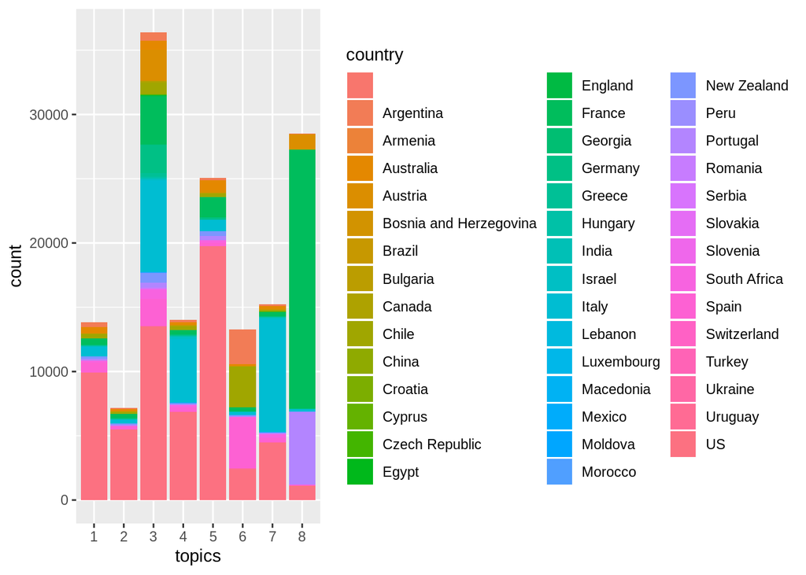

```r
ggplot(data=wine_df, aes(x=topics, fill=country)) + geom_bar()
```

```r
# For each cluster, what's the dominant country of origin?

wines_count <- wine_df %>% count(country, topics)

wines_count <- wines_count %>% merge(priors, by="country")
wines_count['weighted_n'] <- wines_count['n'] / wines_count['frac']

# drop any country with < 1000 wines to its name because it messes with the stats!
wines_count <- wines_count[wines_count['freq'] >=1000, ]
wines_count %>% group_by(topics) %>% top_n(1, weighted_n) -> topic_dominant_country

topic_dominant_country
```

| country | topics | n | freq | frac | weighted_n |
| --- | --- | --- | --- | --- | --- |
| Argentina | 6 | 2700 | 4314 | 0.02810259 | 96076.56 |
| Australia | 1 | 477 | 2627 | 0.01711300 | 27873.54 |
| Germany | 3 | 2191 | 2517 | 0.01639643 | 133626.63 |
| Italy | 4 | 4916 | 23098 | 0.15046675 | 32671.67 |
| Italy | 7 | 8760 | 23098 | 0.15046675 | 58218.84 |
| Portugal | 8 | 5665 | 6645 | 0.04328736 | 130869.60 |
| US | 2 | 5505 | 63442 | 0.41327870 | 13320.31 |
| US | 5 | 19738 | 63442 | 0.41327870 | 47759.54 |

### Looking at the wines

What’s the most representative wine for a given topic? Simply find the wine with the highest probability of belonging to that topic. These are the archetypes, those most similar to all other wines in a group and therefore the wines to try if you want to sample something truly representative!

```r
# What's the most representative single wine for each topic, that for which the topic probability is highest?
wine_df %>% group_by(topics) %>% top_n(1, topic_certainty) -> wine_archetypes
wine_archetypes[,c("topics", "country", "title")]
```

| topics | country | title |
| --- | --- | --- |
| 5 | US | Lazy Creek 2014 Estate Pinot Noir (Anderson Valley) |
| 7 | Italy | Fontodi 2013 Vigna del Sorbo Gran Selezione (Chianti Classico) |
| 6 | Chile | Santa Ema 2011 Catalina Red (Maipo Valley) |
| 1 | Argentina | Lagarde 2010 Guarda Red (Luján de Cuyo) |
| 1 | Argentina | Lagarde 2010 Guarda Red (Luján de Cuyo) |
| 3 | Italy | Selva Capuzza 2015 Selva (Lugana) |
| 2 | US | Girard 2009 Dutton Ranch - Mill Station Chardonnay (Russian River Valley) |
| 4 | South Africa | De Toren 2010 Z Red (Stellenbosch) |
| 8 | France | Château Margaux 2010 Margaux |

## Plot the topic space (SOM’s)

```r
# Define the grid system
som_grid <- somgrid(xdim=30, ydim=30, topo="hexagonal")

# Fit the model (remember, takes vectors or matrices!)
wine_som <- som(as.matrix(wine_df[,18:25]), grid=som_grid, rlen=100, alpha=c(0.05, 0.01))
```

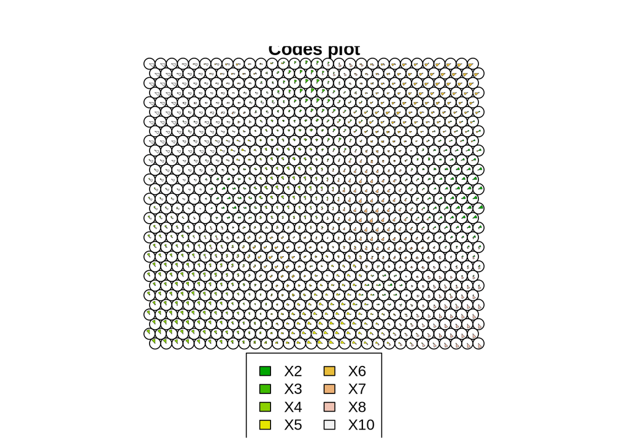

```r
plot(wine_som)
```

## Get the Keyword Labels

```r
# SOM Coordinates for greating my own prettier plot!
som_coords <- data.frame(wine_som$codes)
som_coords["x"] <- wine_som$grid$pts[,1]
som_coords["y"] <- wine_som$grid$pts[,2]

# Once again, assign by maximum probability
som_coords['topics'] <- colnames(som_coords)[apply(som_coords[,1:8], 1, max_index)]
som_coords['topic_conf'] <- apply(som_coords[,1:8], 1, max)

som_coords %>% arrange(topics) -> som_coords

# Finally, for each topic we need to find its x/y medioid (rather than mean, there are distant outliers)
som_coords %>%
  group_by(topics) %>%
  summarize(med_x = median(x), med_y = median(y)) -> som_medioids
```

```r
# Add the keyword information to the medioids dataframe
colnames(word_dist_df)[3] <- "topics"
som_medioids %>% left_join(word_dist_df, by="topics") -> som_medioids
som_medioids['keywords'] <- paste(som_medioids$topics, som_medioids$keywords)
som_medioids
```

| topics | med_x | med_y | X | keywords |
| --- | --- | --- | --- | --- |
| X10 | 4.5 | 20.784610 | 10 | X10 age drink fruiti ripe acid fruit |
| X2 | 27.0 | 13.856406 | 2 | X2 cherri syrah blackberri blend sweet bodi |
| X3 | 16.0 | 22.516660 | 3 | X3 chardonnay butter pineappl sweet vanilla toast |
| X4 | 8.5 | 8.660254 | 4 | X4 appl white lemon citru peach fresh |
| X5 | 17.0 | 4.330127 | 5 | X5 cherri cabernet black spice aroma blend |
| X6 | 22.5 | 21.217622 | 6 | X6 cherri pinot oak cabernet vineyard year |
| X7 | 21.0 | 12.990381 | 7 | X7 feel berri herbal finish plum aroma |
| X8 | 26.5 | 5.196152 | 8 | X8 black tannin cherri palat alongsid aroma |

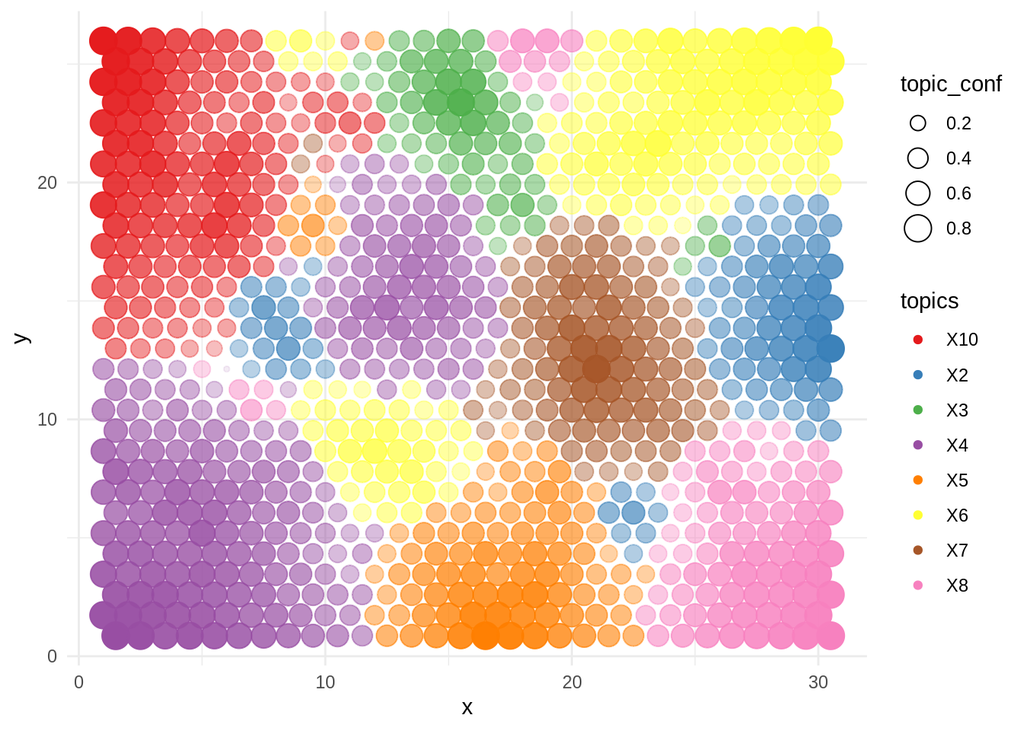

```r
# Create the base plot/colors
som_map <- ggplot(data=som_coords, aes(x=x, y=y, color=topics, fill=topics, size=topic_conf, alpha=topic_conf)) +
  geom_point(pch=21) +
  scale_fill_brewer(palette="Set1") +
  scale_color_brewer(palette="Set1") +
  theme_minimal() +
  guides(alpha=FALSE)

som_map
```

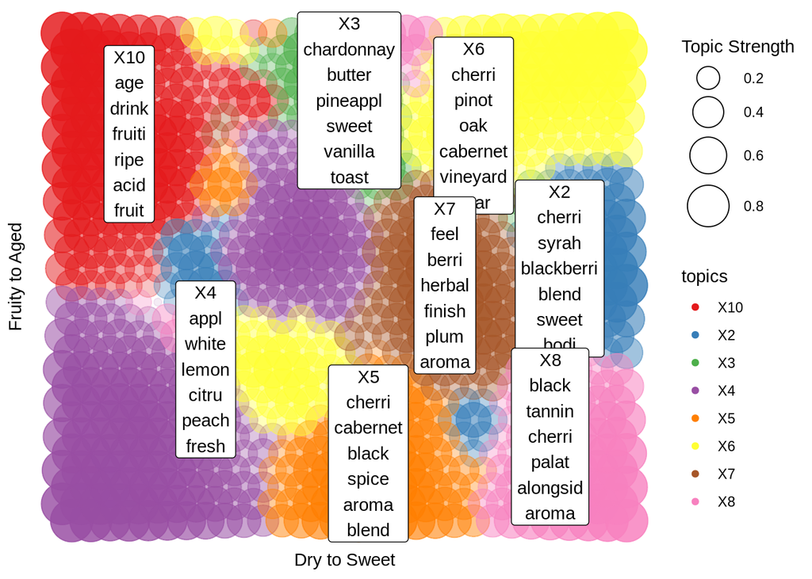

```r
# Create the base plot/colors
som_map <- ggplot(data=som_coords, aes(x=x, y=y, color=topics, fill=topics, size=topic_conf, alpha=topic_conf)) +
  geom_point(pch=21) +
  scale_size_continuous(range = c(2, 12)) +
  labs(x="Dry to Sweet", y="Fruity to Aged", size="Topic Strength") +
  scale_fill_brewer(palette="Set1") +
  scale_color_brewer(palette="Set1") +
  geom_label(data=som_medioids, aes(x=med_x, y=med_y, alpha=1, label=stringr::str_wrap(keywords, 5)), inherit.aes=FALSE) +
  theme_minimal() +
  theme(panel.grid.major = element_blank(),
        panel.grid.minor = element_blank(),
        axis.text.x = element_blank(),
        axis.text.y = element_blank(),
        axis.ticks = element_blank()) +
  guides(alpha=FALSE)

som_map
```

```r
ggsave("flavormap.png", width=12, height=7)
```

## Plot wine-topic profiles by country

```r
# The first thing we need to do is reshape the dataframe to get the topics into long form
wine_df_long <- wine_df[,c("country", "description", "title", "X2", "X3", "X4", "X5", "X6", "X7", "X8", "X10")]
wine_df_long <- melt(wine_df_long, id=c("country", "description", "title"))

# Create some better data for plotting this...
wine_df_long['counter'] <- 1.0
wine_df_long %>% group_by(country, variable) %>% summarize(num_entries = sum(counter), topic_prob = sum(value)) -> sum_tc

sum_tc <- sum_tc %>% filter(num_entries >= 1000) %>% arrange(variable)
sum_tc['topic_prob'] <- sum_tc['topic_prob'] / sum_tc['num_entries']

# Change vairable to character (forces intelligent ordering), reorder
sum_tc['topics'] <- as.character(sum_tc$variable)
sum_tc %>% arrange(topics) -> sum_tc
sum_tc
```

| country | variable | num_entries | topic_prob | topics |
| --- | --- | --- | --- | --- |
| Argentina | X10 | 4314 | 0.03627525 | X10 |
| Australia | X10 | 2627 | 0.04814407 | X10 |
| Austria | X10 | 3999 | 0.21529534 | X10 |
| Chile | X10 | 5060 | 0.03518057 | X10 |
| France | X10 | 27405 | 0.47417805 | X10 |
| Germany | X10 | 2517 | 0.04020194 | X10 |
| Italy | X10 | 23098 | 0.03254975 | X10 |
| New Zealand | X10 | 1705 | 0.04148616 | X10 |
| Portugal | X10 | 6645 | 0.54024286 | X10 |
| South Africa | X10 | 1601 | 0.05017167 | X10 |

[output cut: 86 more lines]

## Some exploratory test plots

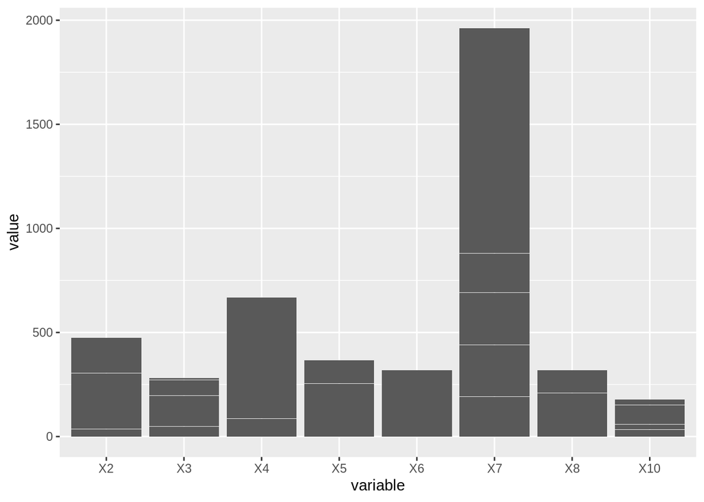

```r
# Note;  I should probably limit this later to countries with > 1000 wines!
subset <- wine_df_long[wine_df_long["country"]=="Chile",]
ggplot(subset, aes(x=variable, y=value)) + geom_col()
```

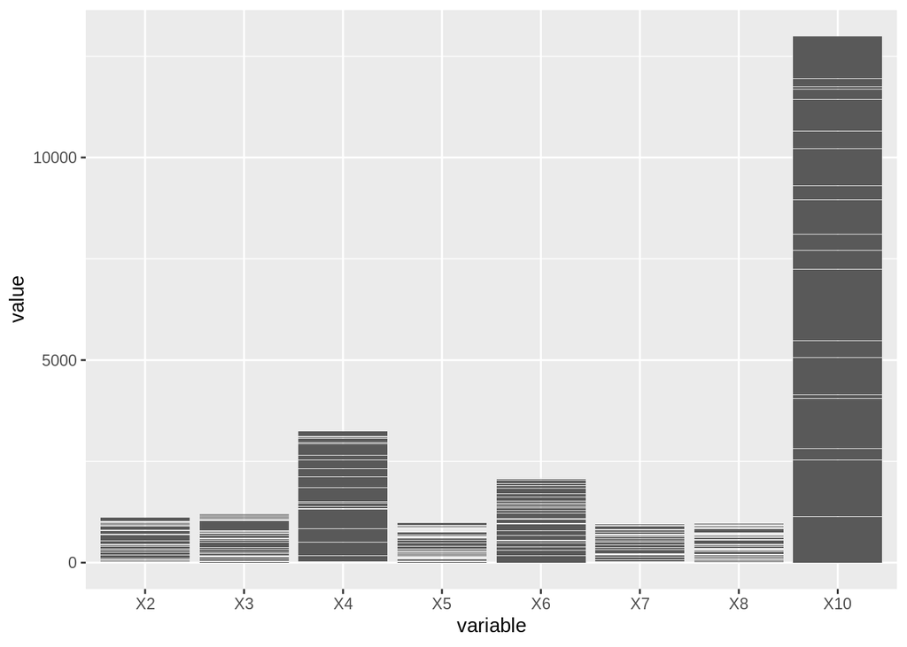

```r
# Note;  I should probably limit this later to countries with > 1000 wines!
subset <- wine_df_long[wine_df_long["country"]=="France",]
ggplot(subset, aes(x=variable, y=value)) + geom_col()
```

## Final developed plot!

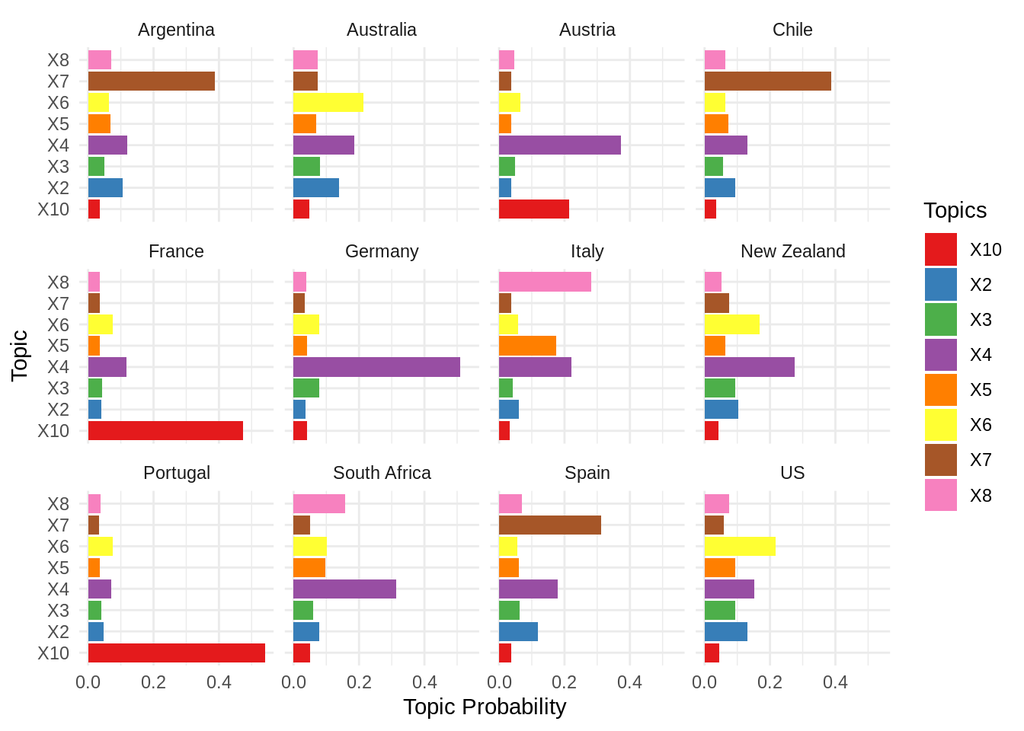

```r
# Note:  Need to fix the ordering!
ggplot(sum_tc, aes(x=topics, y=topic_prob, fill=topics)) +
  scale_fill_brewer(palette="Set1") +
  labs(x="Topic", y="Topic Probability", fill = "Topics") +
  geom_col() +
  coord_flip() +
  facet_wrap(vars(country)) +
  theme_minimal()
```